# Homework 07

Use either R or Python.

## Question 1: LDA

Let’s start by estimating the components of LDA. From the lecture notes, for each target point $\mathbf{x}_0$, we find the class label $k$ with the largest score

$$\mathbf{x}_0^{\mathsf T}\boldsymbol{\Sigma}^{-1}\boldsymbol{\mu}_k
-\frac12\boldsymbol{\mu}_k^{\mathsf T}\boldsymbol{\Sigma}^{-1}\boldsymbol{\mu}_k
+\log\pi_k.$$

Thus, we need to estimate:

- the prior probabilities $\pi_k$;
- the mean vector (centroid) $\boldsymbol{\mu}_k$ for each class; and
- the pooled covariance matrix $\boldsymbol{\Sigma}$.

Use saheart.csv, the `SAheart` data from `ElemStatLearn`. The two classes are defined by `chd`, the coronary heart disease indicator. Use all nine other variables as numerical predictors, coding `famhist` as 1 for `Absent` and 2 for `Present`. The following code constructs an $n\times9$ predictor matrix $\mathbf{X}$ and an $n$-entry response vector $\mathbf{y}$, where $n$ is the number of observations.

**R**

```r
heart <- read.csv("data/saheart.csv")
heart$famhist <- factor(heart$famhist, levels = c("Absent", "Present"))
X <- data.matrix(heart[, names(heart) != "chd"])
y <- heart$chd
```

**Python**

```python
import pandas as pd

heart = pd.read_csv("data/saheart.csv")
heart["famhist"] = heart["famhist"].map({"Absent": 1, "Present": 2})
X = heart.drop(columns="chd").to_numpy()
y = heart["chd"].to_numpy()
```

1. Calculate the prior probabilities, class means, and pooled covariance matrix from these data. Use the pooled covariance denominator $n-K$ from the lecture, where $K=2$ is the number of classes.
2. Use your estimated values to predict the label of each observation in the training data. These are in-sample fitted labels. Provide the confusion matrix, with observed classes in rows and predicted classes in columns. Check that the dimensions of your matrices and vectors match. Calculate the scores yourself for this part.
3. Perform the same LDA analysis using `MASS::lda` in R or `LinearDiscriminantAnalysis(solver="svd")` in Python, using the same numerical predictors and empirical class priors. Provide the confusion matrix. Do the results match?

**Answer 1.** I coded `famhist` as 1 = Absent and 2 = Present and used the other eight columns as given, so $\mathbf X$ is $462\times 9$.

**Show the workflow**

```python
import numpy as np
import pandas as pd
import matplotlib.pyplot as plt
from sklearn.discriminant_analysis import (LinearDiscriminantAnalysis,
                                           QuadraticDiscriminantAnalysis)

heart = pd.read_csv("data/saheart.csv")
heart["famhist"] = heart["famhist"].map({"Absent": 1, "Present": 2})
X = heart.drop(columns="chd").to_numpy()
y = heart["chd"].to_numpy()
predictor_names = heart.drop(columns="chd").columns
n, p = X.shape
classes = np.unique(y)
K = len(classes)
print(f"n = {n}, p = {p}, K = {K}")
```

```
n = 462, p = 9, K = 2
```

**a.** The prior is the class proportion, $\hat\pi_k=n_k/n$. The centroid is the class mean, and the pooled covariance is

$$\widehat{\boldsymbol\Sigma}=\frac{1}{n-K}\sum_{k=1}^K\sum_{i:y_i=k}(\mathbf x_i-\hat{\boldsymbol\mu}_k)(\mathbf x_i-\hat{\boldsymbol\mu}_k)^{\mathsf T}.$$

**Show the workflow**

```python
pi_hat = np.array([np.mean(y == k) for k in classes])          # length K
mu_hat = np.vstack([X[y == k].mean(axis=0) for k in classes])  # K x p
Sigma_hat = sum(
    (X[y == k] - mu_hat[j]).T @ (X[y == k] - mu_hat[j])
    for j, k in enumerate(classes)
) / (n - K)                                                      # p x p

print("Priors:", dict(zip(classes, pi_hat.round(4))))
print("\nClass means (rows = chd):")
print(pd.DataFrame(mu_hat, index=classes, columns=predictor_names).round(4)
      .to_string())
print("\nPooled covariance:")
print(pd.DataFrame(Sigma_hat, index=predictor_names, columns=predictor_names)
      .round(3).to_string())
```

```
Priors: {np.int64(0): np.float64(0.6537), np.int64(1): np.float64(0.3463)}

Class means (rows = chd):
        sbp  tobacco     ldl  adiposity  famhist    typea  obesity  alcohol      age
0  135.4603   2.6347  4.3442    23.9691   1.3179  52.3675  25.7375  15.9314  38.8543
1  143.7375   5.5249  5.4879    28.1202   1.6000  54.4938  26.6229  19.1452  50.2938

Pooled covariance:
               sbp  tobacco    ldl  adiposity  famhist   typea  obesity  alcohol      age
sbp        405.435   14.585  4.581     49.164    0.337 -15.588   18.939   64.400   95.134
tobacco     14.585   19.243  0.763      7.538    0.016  -2.057    1.833   20.517   22.765
ldl          4.581    0.763  4.001      6.033    0.092   0.345    2.660   -2.533    6.479
adiposity   49.164    7.538  6.033     56.753    0.433  -5.310   22.708   16.119   60.509
famhist      0.337    0.016  0.092      0.433    0.226   0.081    0.184    0.768    0.997
typea      -15.588   -2.057  0.345     -5.310    0.081  95.566    2.640    7.960  -20.278
obesity     18.939    1.833  2.660     22.708    0.184   2.640   17.615    4.689   15.697
alcohol     64.400   20.517 -2.533     16.119    0.768   7.960    4.689  598.277   27.886
age         95.134   22.765  6.479     60.509    0.997 -20.278   15.697   27.886  184.132
```

The priors are $\hat\pi_0=302/462=0.6537$ and $\hat\pi_1=160/462=0.3463$. People with CHD are older on average (50.3 vs 38.9 years) and have higher tobacco use, LDL, adiposity, and blood pressure.

**b.** I computed the $n\times K$ score matrix with one matrix product per term and took the class with the largest score in each row.

**Show the workflow**

```python
Sigma_inv = np.linalg.inv(Sigma_hat)
assert X.shape == (n, p) and mu_hat.shape == (K, p)
assert Sigma_inv.shape == (p, p) and pi_hat.shape == (K,)

scores = (X @ Sigma_inv @ mu_hat.T                                # n x K
          - 0.5 * np.sum((mu_hat @ Sigma_inv) * mu_hat, axis=1)    # K
          + np.log(pi_hat))                                        # K
assert scores.shape == (n, K)
y_hat_manual = classes[np.argmax(scores, axis=1)]

cm_manual = pd.crosstab(pd.Series(y, name="Observed"),
                        pd.Series(y_hat_manual, name="Predicted"))
print(cm_manual)
print("Training error:", round(np.mean(y_hat_manual != y), 4))
```

```
Predicted    0   1
Observed
0          258  44
1           73  87
Training error: 0.2532
```

|  | Predicted 0 | Predicted 1 |
| --- | --- | --- |
| **Observed 0** | 258 | 44 |
| **Observed 1** | 73 | 87 |

The in-sample misclassification rate is $(44+73)/462=0.2532$.

**c.**

**Show the workflow**

```python
lda_fit = LinearDiscriminantAnalysis(solver="svd").fit(X, y)  # priors = class proportions
y_hat_sklearn = lda_fit.predict(X)
print(pd.crosstab(pd.Series(y, name="Observed"),
                  pd.Series(y_hat_sklearn, name="Predicted")))
print("Priors used:", lda_fit.priors_.round(4))
print("Identical labels:", np.array_equal(y_hat_sklearn, y_hat_manual))
print("Max |mean difference|:", np.abs(lda_fit.means_ - mu_hat).max())
```

```
Predicted    0   1
Observed
0          258  44
1           73  87
Priors used: [0.6537 0.3463]
Identical labels: True
Max |mean difference|: 0.0
```

Yes, the results match. `LinearDiscriminantAnalysis` uses the same empirical priors (0.6537, 0.3463), gives the same 258/44/73/87 confusion matrix, and predicts the same label for all 462 observations. Its class means are the same as mine. The `svd` solver never forms $\widehat{\boldsymbol\Sigma}^{-1}$ directly. It whitens the class-centered data with an SVD, also using the $1/(n-K)$ scaling, which gives the same discriminant rule.

## Question 2: QDA and marginal screening

In the lecture, ordinary QDA could not be fitted to the handwritten digit sample because its within-class covariance matrices were singular. Let’s consider selecting fewer variables and see whether this helps. For this question, use the full zip-train.csv.gz as the training data and zip-test.csv.gz as the test data, with all ten digit classes. These are the original `zip.train` and `zip.test` data from `ElemStatLearn`. Each file has no header: the first column is the digit label and the remaining 256 columns are pixel values.

Instead of using all 256 predictors, select the 40 with the largest marginal variances in the training data. Here, marginal variance means the variance of one pixel across all training observations. Use the original pixel values without standardizing them, and retain the same selected predictors in the test data.

Use `MASS::qda` in R or `QuadraticDiscriminantAnalysis(tol=1e-8)` in Python.

1. Fit QDA using these 40 predictors and report the test confusion matrix, with observed classes in rows and predicted classes in columns. Also report the test misclassification rate.
2. Does the method work? Why do you think it works or does not work?
3. Repeat the analysis using the 10 predictors with the largest marginal variances in the training data. How does the test misclassification rate compare with the 40-predictor version? Why do you think this happens?

**Answer 2.** The training set has 7,291 images and the test set has 2,007. I ranked the 256 pixels by their sample variance over all training images (ignoring the label), kept the top 40, and used the same pixel columns in the test data.

**Show the workflow**

```python
zip_train = np.loadtxt("data/zip-train.csv.gz", delimiter=",")
zip_test = np.loadtxt("data/zip-test.csv.gz", delimiter=",")
X_train, y_train = zip_train[:, 1:], zip_train[:, 0].astype(int)
X_test, y_test = zip_test[:, 1:], zip_test[:, 0].astype(int)

pixel_var = X_train.var(axis=0, ddof=1)       # marginal variance of each pixel
rank = np.argsort(pixel_var)[::-1]

def fit_qda_top(m):
    keep = rank[:m]
    qda = QuadraticDiscriminantAnalysis(tol=1e-8).fit(X_train[:, keep], y_train)
    pred = qda.predict(X_test[:, keep])
    cm = (pd.crosstab(pd.Series(y_test, name="Observed"),
                      pd.Series(pred, name="Predicted"))
          .reindex(index=range(10), columns=range(10), fill_value=0))
    return keep, pred, cm

print("Training images per digit:", np.bincount(y_train))
```

```
Training images per digit: [1194 1005  731  658  652  556  664  645  542  644]
```

**a.**

**Show the workflow**

```python
keep40, pred40, cm40 = fit_qda_top(40)
print(cm40)
print("Test misclassification rate:", round(np.mean(pred40 != y_test), 4))
```

```
Predicted    0    1    2    3    4    5    6    7    8    9
Observed
0          319    0   24    6    2    2    1    0    5    0
1            0  238    5    0   11    0    7    0    3    0
2            8    0  168    8    8    3    0    0    3    0
3            5    0    4  128    0   14    0    0   15    0
4            0    2   13    1  150    1    0    1    7   25
5           12    0    3    5    1  131    0    0    6    2
6            0    0    8    0    1    8  148    0    5    0
7            1    0    6    1    6    0    0  124    2    7
8            1    0   10   12    3    2    0    0  137    1
9            0    0    1    2    7    1    1    4    9  152
Test misclassification rate: 0.1555
```

The test misclassification rate with 40 pixels is **0.1555** (312 of 2,007 images).

**b.** Yes, the method works. QDA fits without a singularity error or collinearity warning, and the test error of 15.5% is far better than chance (90%). For comparison, LDA on the same 40 pixels has a test error of 0.234, so letting each digit have its own covariance helps.

**Show the workflow**

```python
min_eig = [np.linalg.eigvalsh(np.cov(X_train[y_train == k][:, keep40].T)).min()
           for k in range(10)]
print("Smallest eigenvalue of each class covariance:",
      np.array(min_eig).round(7))
lda40 = LinearDiscriminantAnalysis().fit(X_train[:, keep40], y_train)
print("LDA test error with the same 40 pixels:",
      round(np.mean(lda40.predict(X_test[:, keep40]) != y_test), 4))
```

```
Smallest eigenvalue of each class covariance: [1.94140e-03 3.00000e-07 1.54489e-02 1.08556e-02 1.04771e-02 1.71698e-02
 3.38380e-03 2.34040e-03 3.26540e-02 5.69590e-03]
LDA test error with the same 40 pixels: 0.2337
```

It works because the two causes of singularity are gone.

- **Constant pixels.** With all 256 pixels, some pixels never change within a class (99 pixels for digit 1, 23 for digit 7, 18 for digit 9). A pixel with zero within-class variance makes that class covariance singular. Pixels with the largest marginal variance sit in the middle of the image where strokes vary, so they almost never stay constant within a class.
- **Too few observations per parameter.** Each class needs a $40\times40$ covariance with 820 free entries, estimated from 542 to 1,194 images. Every class has many more images than the 40 dimensions, so its sample covariance can be full rank.

Every class covariance has a positive smallest eigenvalue. Digit 1 comes closest to singular (about $3\times10^{-7}$), because a thin vertical stroke leaves some selected pixels almost always blank. That is still above the `tol=1e-8` threshold, so QDA can invert it. The remaining errors make visual sense: true 4s predicted as 9 (25), 0s as 2 (24), and 3s as 8 or 5 (15 and 14).

**c.**

**Show the workflow**

```python
keep10, pred10, cm10 = fit_qda_top(10)
print(cm10)
print("Test misclassification rate:", round(np.mean(pred10 != y_test), 4))
```

```
Predicted    0    1   2    3   4   5   6    7   8    9
Observed
0          298    0  11    1   1  16  28    4   0    0
1            0  241  10    0   3   1   1    0   2    6
2           19    2  95   14  14   3  22   21   5    3
3            5    0   6  103   3  42   0    0   7    0
4            1    5  14    0  95   2   4   15  17   47
5           15    0   6   25   4  96   4    2   8    0
6           41    0  15    4   0  18  78    7   5    2
7            4    1   6    0   6   0   1  122   0    7
8            1    2  11   36  12  11   4    1  74   14
9            0    2   9    2  20   0   0   16  10  118
Test misclassification rate: 0.3423
```

With 10 pixels the test misclassification rate rises to **0.3423**, more than double the 40-pixel rate of 0.1555. Using fewer predictors reduces variance, since each class covariance now has only 55 free entries. That isn’t the problem here, though: with over 500 images per class, the 40-pixel model was already estimated well. The 10-pixel model loses too much information. Ten pixels cannot describe the shape of a digit, so many digits look alike at those locations. Errors spread across many pairs, for example 3 and 5 (42 and 25 in each direction), 4 and 9 (47), and 6 and 0 (41). Marginal variance is also an unsupervised criterion. It picks pixels that vary a lot overall, not pixels that separate the classes, so several of the top 10 are neighboring pixels in the center of the image that carry overlapping information. Here, the extra bias from dropping 30 informative pixels outweighs any variance saved.

## Question 3: Compare LDA and QDA

In this simulation, we will study how the relative performance of LDA and QDA changes with the true covariance structure. The parameter $\rho$ controls the distribution from which we generate the data; it is not a tuning parameter of LDA or QDA.

Consider a classification problem with two equally likely classes, labeled 1 and 2, and $p=10$ covariates. The first two covariates have the class-conditional distributions

$$\begin{pmatrix}X_1\\X_2\end{pmatrix}\mid Y=1
\sim N_2\left(
\begin{pmatrix}-1\\0\end{pmatrix},
\begin{pmatrix}1&\rho\\\rho&1\end{pmatrix}
\right),$$

$$\begin{pmatrix}X_1\\X_2\end{pmatrix}\mid Y=2
\sim N_2\left(
\begin{pmatrix}1\\0\end{pmatrix},
\begin{pmatrix}1&-\rho\\-\rho&1\end{pmatrix}
\right).$$

In both classes, the remaining eight covariates are independent standard normal variables, independent of the first two. Consider

$$\rho\in\{0,0.2,0.4,0.6,0.8,0.9\}.$$

For each value of $\rho$, generate 100 training observations and 1,000 independent test observations from each class. Fit ordinary LDA and QDA using all 10 covariates and equal class priors. Estimate the class means from the training data, with one pooled covariance matrix for LDA and one full covariance matrix per class for QDA. Set a random seed and report it.

1. Generate one dataset for each value of $\rho$. Fit both methods and calculate their test misclassification rates. Within each setting, use the same training and test observations for the two methods.
2. At each fixed value of $\rho$, repeat the experiment 50 times, generating new training and test observations in each repetition. Plot average test error against $\rho$ in one figure, with one curve for LDA and one for QDA. These curves compare performance across different data-generating distributions.
3. Compare the two methods at small and large values of $\rho$. How does changing the true covariance structure affect their relative performance? Explain the pattern using their covariance assumptions and the bias-variance trade-off. How can the eight noise covariates affect performance even though they contain no information about the class label?

**Answer 3.** I used seed `432` (NumPy `default_rng`) for the whole question: part a first, then the 50 repetitions in part b, from the same generator. Both methods use equal priors, `priors=[0.5, 0.5]`.

**Show the workflow**

```python
q3_rng = np.random.default_rng(432)
rhos = [0, 0.2, 0.4, 0.6, 0.8, 0.9]

def generate(n_per_class, rho, rng):
    X_parts = []
    for mean_x1, r in [(-1, rho), (1, -rho)]:          # class 1, then class 2
        cov = np.array([[1, r], [r, 1]])
        X12 = rng.multivariate_normal([mean_x1, 0], cov, size=n_per_class)
        noise = rng.standard_normal((n_per_class, 8))  # 8 noise covariates
        X_parts.append(np.hstack([X12, noise]))
    return np.vstack(X_parts), np.repeat([1, 2], n_per_class)

def one_experiment(rho, rng):
    X_tr, y_tr = generate(100, rho, rng)
    X_te, y_te = generate(1000, rho, rng)
    lda = LinearDiscriminantAnalysis(priors=[0.5, 0.5]).fit(X_tr, y_tr)
    qda = QuadraticDiscriminantAnalysis(priors=[0.5, 0.5]).fit(X_tr, y_tr)
    return (np.mean(lda.predict(X_te) != y_te),
            np.mean(qda.predict(X_te) != y_te))
```

**a.**

**Show the workflow**

```python
q3a = pd.DataFrame([(r, *one_experiment(r, q3_rng)) for r in rhos],
                   columns=["rho", "LDA test error", "QDA test error"])
print(q3a.round(4).to_string(index=False))
```

```
 rho  LDA test error  QDA test error
 0.0          0.1710          0.2010
 0.2          0.1715          0.1810
 0.4          0.1575          0.1715
 0.6          0.1535          0.1605
 0.8          0.1815          0.1495
 0.9          0.1815          0.1030
```

| $\rho$ | LDA | QDA |
| --- | --- | --- |
| 0 | 0.1710 | 0.2010 |
| 0.2 | 0.1715 | 0.1810 |
| 0.4 | 0.1575 | 0.1715 |
| 0.6 | 0.1535 | 0.1605 |
| 0.8 | 0.1815 | 0.1495 |
| 0.9 | 0.1815 | 0.1030 |

In this single dataset per setting, LDA is better up to $\rho=0.6$ and QDA is better at $\rho=0.8$ and $0.9$.

**b.**

**Show the workflow**

```
 rho    LDA    QDA  SE LDA  SE QDA
 0.0 0.1706 0.1952  0.0016  0.0020
 0.2 0.1691 0.1943  0.0012  0.0019
 0.4 0.1687 0.1894  0.0014  0.0017
 0.6 0.1690 0.1761  0.0013  0.0013
 0.8 0.1700 0.1381  0.0015  0.0013
 0.9 0.1677 0.0996  0.0013  0.0010
```

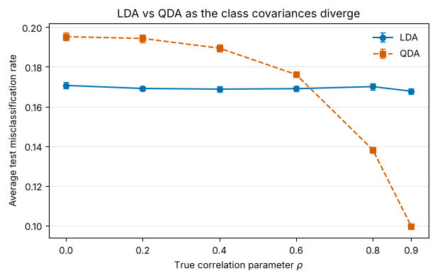

Average test misclassification rate over 50 repetitions at each value of rho. Error bars show plus or minus one standard error.

```python
nsim = 50
q3b = np.array([[one_experiment(r, q3_rng) for _ in range(nsim)] for r in rhos])
avg = q3b.mean(axis=1)                          # len(rhos) x 2
se = q3b.std(axis=1, ddof=1) / np.sqrt(nsim)
print(pd.DataFrame({"rho": rhos, "LDA": avg[:, 0], "QDA": avg[:, 1],
                    "SE LDA": se[:, 0], "SE QDA": se[:, 1]})
      .round(4).to_string(index=False))

fig, ax = plt.subplots(figsize=(6.5, 4.2))
ax.errorbar(rhos, avg[:, 0], yerr=se[:, 0], marker="o", capsize=3,
            color="#0072B2", label="LDA")
ax.errorbar(rhos, avg[:, 1], yerr=se[:, 1], marker="s", capsize=3,
            linestyle="--", color="#D55E00", label="QDA")
ax.set_xlabel(r"True correlation parameter $\rho$")
ax.set_ylabel("Average test misclassification rate")
ax.set_title("LDA vs QDA as the class covariances diverge")
ax.set_xticks(rhos)
ax.grid(axis="y", color="0.9")
ax.legend(frameon=False)
plt.tight_layout()
plt.show()
```

| $\rho$ | LDA | QDA |
| --- | --- | --- |
| 0 | 0.1706 | 0.1952 |
| 0.2 | 0.1691 | 0.1943 |
| 0.4 | 0.1687 | 0.1894 |
| 0.6 | 0.1690 | 0.1761 |
| 0.8 | 0.1700 | 0.1381 |
| 0.9 | 0.1677 | 0.0996 |

**c. Small $\rho$.** At $\rho=0$, both classes have the identity covariance, so LDA’s equal-covariance assumption is exactly right and the Bayes boundary is linear. QDA estimates the same thing with far more parameters: a separate $10\times10$ covariance per class, $2\times55=110$ entries from only 100 observations per class, compared with 55 pooled entries from 200 observations for LDA. The extra flexibility adds variance with no reduction in bias, so QDA is worse (0.195 vs 0.171). For $\rho\le0.4$ the true boundary is only slightly curved, and LDA still wins.

**Large $\rho$.** The two classes have opposite correlations between $X_1$ and $X_2$. Their pooled covariance is about the identity, because $\rho$ and $-\rho$ average out, so LDA cannot see the correlation at all. It always draws roughly the boundary $x_1=0$, and its error stays near $\Phi(-1)\approx0.159$ plus some estimation error, about 0.17 for every $\rho$. That is a bias: the class difference in covariance carries information about the label that a linear rule cannot use. QDA estimates each class covariance and gets a curved boundary that uses the sign of $X_1X_2$. Its bias shrinks as $\rho$ grows, while its variance stays about the same, so its error drops from 0.195 to 0.100. The curves cross between $\rho=0.6$ and $0.8$, where the bias LDA gives up becomes larger than the variance QDA pays.

**Noise covariates.** The eight noise covariates don’t help separate the classes, but both methods still estimate parameters for them. QDA pays the most. Of its 55 covariance entries per class, only 3 involve $X_1$ and $X_2$ alone, and the rest are noise. Their sample values are never exactly 0 or 1, so the estimated boundary curves in directions that are irrelevant, which adds variance and test error. LDA’s extra cost grows only with the 8 extra mean differences and one shared covariance, so it is hurt less. The check below refits both methods on $X_1$ and $X_2$ only (seed `4320`). Without the noise covariates, the two tie at $\rho=0$, both curves are lower, and QDA already wins at $\rho=0.6$, so the crossover moves to a smaller $\rho$.

**Show the workflow**

```python
check_rng = np.random.default_rng(4320)
def two_cov_experiment(rho, rng):
    X_tr, y_tr = generate(100, rho, rng)
    X_te, y_te = generate(1000, rho, rng)
    X_tr, X_te = X_tr[:, :2], X_te[:, :2]        # drop the 8 noise covariates
    lda = LinearDiscriminantAnalysis(priors=[0.5, 0.5]).fit(X_tr, y_tr)
    qda = QuadraticDiscriminantAnalysis(priors=[0.5, 0.5]).fit(X_tr, y_tr)
    return (np.mean(lda.predict(X_te) != y_te),
            np.mean(qda.predict(X_te) != y_te))
two_cov = np.array([[two_cov_experiment(r, check_rng) for _ in range(nsim)]
                    for r in rhos]).mean(axis=1)
print(pd.DataFrame({"rho": rhos, "LDA (2 covariates)": two_cov[:, 0],
                    "QDA (2 covariates)": two_cov[:, 1]})
      .round(4).to_string(index=False))
```

```
 rho  LDA (2 covariates)  QDA (2 covariates)
 0.0              0.1581              0.1584
 0.2              0.1604              0.1617
 0.4              0.1604              0.1620
 0.6              0.1613              0.1532
 0.8              0.1572              0.1159
 0.9              0.1584              0.0858
```

## Question 4: Create and use an LDA/QDA analysis skill

In Homework 5, you created a skill for formatting plots. Now create a reusable skill that guides an AI agent through an LDA/QDA analysis and produces a concise statistical report. You may work with AI to design and write the skill; you do not need to write every line yourself.

1. **Define the skill.** Write a single `SKILL.md` file no larger than **5 KB (5,000 bytes)**. Define the agent’s behavior, analysis guidelines, and expected report structure. Keep the skill independent of this question: provide the dataset, response, and predictors separately when invoking it. The skill may guide the agent to explore lower-dimensional representations, such as principal component analysis (PCA), or to blend the class probabilities predicted by LDA and QDA. Keep all classifiers based on LDA, QDA, or their combination. Configure the skill to load **only when you explicitly invoke it**. Use your AI tool’s invocation settings, or keep the file outside automatically loaded skill folders and supply it only in an explicit request.

Your skill must require a clearly readable analysis report of **at most one printed page**, containing a figure, a table, and numerical model-fitting results. You may specify the type and style of figures and tables you want the AI to produce. All instructions in the skill must be independent of the actual dataset, its variable names, and its observed results. The report should briefly describe the candidate models, the cross-validation procedure and results, the selected model, and its estimated prediction error. It should explain the main findings and any limitations.

2. **Apply the skill.** Explicitly invoke your skill to analyze the `SAheart` data from Question 1, using the same response and predictor coding. Ask the agent to seek the best predictive performance within the LDA/QDA methods allowed by your skill. Include ordinary LDA and QDA as comparisons; the extensions above are optional. Reserve a test set before choosing models. Use the same cross-validation folds within the training data to compare candidates and select any settings. Estimate any preprocessing, including an embedding, using only the training observations in each fold. Refit the selected model and preprocessing on all training observations, then evaluate the fitted classifier once on the reserved test set. Use misclassification rate to compare performance, and report your random seed.
3. **Review and submit.** Check the agent’s analysis and make any skill revisions using only training and cross-validation results. Append the final one-page analysis report and the complete contents of your `SKILL.md` to your homework report. State the file size and briefly explain how you enabled explicit invocation, including the prompt used to apply the skill. The one-page limit applies to the analysis report; the appended skill and this explanation are outside that limit.

Your skill and analysis report will be reviewed and graded by other students through peer evaluation.

**Answer 4.** For **a**, the skill is saved at `skills/lda-qda-report/SKILL.md` inside this homework folder, and its full contents are appended at the end of this answer. For **b**, the one-page report it produced follows. For **c**, my review and the invocation details come after the report.

### SAheart LDA/QDA analysis report

**Setup.** Response `chd`, nine predictors with the Question 1 coding (Python, scikit-learn 1.7.2), seed 432. A stratified 25% test set (116 people, 40 with CHD) was reserved before modeling, leaving 346 for training. All candidates share one stratified 10-fold split of the training set, with scaling and PCA refit inside each fold.

**Show the workflow**

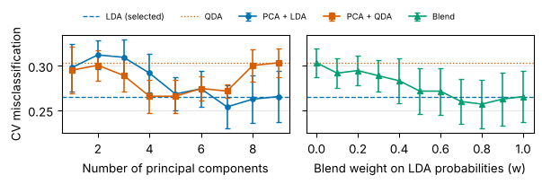

Mean 10-fold CV misclassification rate (bars: plus or minus 1 SE). Horizontal lines mark ordinary LDA (selected) and QDA.

```python
from sklearn.model_selection import train_test_split, StratifiedKFold
from sklearn.pipeline import make_pipeline
from sklearn.preprocessing import StandardScaler
from sklearn.decomposition import PCA
from sklearn.base import clone

SEED = 432
X4, y4 = X, y                                   # Question 1 coding, 462 x 9
X_tr4, X_te4, y_tr4, y_te4 = train_test_split(
    X4, y4, test_size=0.25, stratify=y4, random_state=SEED)
folds = list(StratifiedKFold(n_splits=10, shuffle=True, random_state=SEED)
             .split(X_tr4, y_tr4))              # shared by every candidate

def cv_errors(fit_predict):
    return np.array([np.mean(fit_predict(X_tr4[a], y_tr4[a], X_tr4[b]) != y_tr4[b])
                     for a, b in folds])

def model_fp(model):
    return lambda Xa, ya, Xb: clone(model).fit(Xa, ya).predict(Xb)

def blend_fp(w):
    def fp(Xa, ya, Xb):
        p_lda = LinearDiscriminantAnalysis().fit(Xa, ya).predict_proba(Xb)
        p_qda = QuadraticDiscriminantAnalysis().fit(Xa, ya).predict_proba(Xb)
        return np.unique(ya)[np.argmax(w * p_lda + (1 - w) * p_qda, axis=1)]
    return fp

rows = []
def add(family, setting, fp):
    e = cv_errors(fp)
    rows.append({"family": family, "setting": setting,
                 "cv": e.mean(), "se": e.std(ddof=1) / np.sqrt(len(folds))})

add("LDA", "all 9 predictors", model_fp(LinearDiscriminantAnalysis()))
add("QDA", "all 9 predictors", model_fp(QuadraticDiscriminantAnalysis()))
for d in range(1, X4.shape[1] + 1):             # scaler + PCA refit inside each fold
    add("PCA + LDA", d, model_fp(make_pipeline(StandardScaler(), PCA(d),
                                               LinearDiscriminantAnalysis())))
    add("PCA + QDA", d, model_fp(make_pipeline(StandardScaler(), PCA(d),
                                               QuadraticDiscriminantAnalysis())))
weights = np.round(np.arange(0, 1.01, 0.1), 1)
for w in weights:
    add("Blend", w, blend_fp(w))
cv = pd.DataFrame(rows)

# Selection: one-SE rule, then the skill's simplicity order.
best = cv.loc[cv["cv"].idxmin()]
threshold = best["cv"] + best["se"]
order = {"LDA": 0, "QDA": 1, "PCA + LDA": 2, "PCA + QDA": 3, "Blend": 4}
def simplicity(row):
    if row.family == "Blend":
        return (4, -float(row.setting))          # w closest to 1 first
    if row.family.startswith("PCA"):
        return (order[row.family], int(row.setting))  # fewest components first
    return (order[row.family], 0)
selected = min(cv[cv["cv"] <= threshold].itertuples(), key=simplicity)

final = LinearDiscriminantAnalysis().fit(X_tr4, y_tr4)  # selected model, refit on all training data
assert selected.family == "LDA"
pred_te = final.predict(X_te4)                           # the test set is used once, here
test_err = np.mean(pred_te != y_te4)
cm_te = pd.crosstab(pd.Series(y_te4, name="Observed"), pd.Series(pred_te, name="Predicted"))

lda_cv = cv.loc[cv["family"] == "LDA", "cv"].item()
qda_cv = cv.loc[cv["family"] == "QDA", "cv"].item()
fig, axes = plt.subplots(1, 2, figsize=(6.5, 2.1), sharey=True)
for fam, col, mk in [("PCA + LDA", "#0072B2", "o"), ("PCA + QDA", "#D55E00", "s")]:
    sub = cv[cv["family"] == fam]
    axes[0].errorbar(sub["setting"].astype(int), sub["cv"], yerr=sub["se"], color=col,
                     marker=mk, ms=4, capsize=2, lw=1.2, label=fam)
sub = cv[cv["family"] == "Blend"]
axes[1].errorbar(sub["setting"].astype(float), sub["cv"], yerr=sub["se"], color="#009E73",
                 marker="^", ms=4, capsize=2, lw=1.2, label="Blend")
for ax in axes:
    ax.axhline(lda_cv, color="#0072B2", ls="--", lw=1, label="LDA (selected)")
    ax.axhline(qda_cv, color="#D55E00", ls=":", lw=1, label="QDA")
    ax.grid(axis="y", color="0.9")
axes[0].set(xlabel="Number of principal components", ylabel="CV misclassification")
axes[1].set(xlabel="Blend weight on LDA probabilities (w)")
labels = ["LDA (selected)", "QDA", "PCA + LDA", "PCA + QDA", "Blend"]
h0, l0 = axes[0].get_legend_handles_labels()
h1, l1 = axes[1].get_legend_handles_labels()
lookup = dict(zip(l0 + l1, h0 + h1))
fig.legend([lookup[k] for k in labels], labels, loc="upper center", ncol=5,
           fontsize=7, frameon=False, bbox_to_anchor=(0.5, 1.02))
plt.tight_layout(rect=(0, 0, 1, 0.92))
plt.show()
```

| Candidate (best setting per family) | CV error | CV SE | Settings |
| --- | --- | --- | --- |
| **LDA (selected)** | **0.266** | **0.028** | all 9 predictors |
| QDA | 0.304 | 0.016 | all 9 predictors |
| PCA + LDA | 0.254 | 0.025 | 7 components (lowest CV error) |
| PCA + QDA | 0.266 | 0.019 | 4 components |
| Blend of LDA and QDA | 0.257 | 0.027 | w = 0.8 |

**Selected model and test result.** The lowest CV error is 0.254 (PCA + LDA, 7 components, SE 0.025). Ordinary LDA (0.266) is within one SE, so the one-SE rule selects it. Refit on all training data, LDA has a **test misclassification rate of 0.276** (32 of 116), versus 0.345 for always predicting no CHD. Test confusion matrix (rows observed, columns predicted): [64, 12; 20, 20], so sensitivity is 0.50 and specificity 0.84.

**Findings.** Shared-covariance methods did best: QDA (0.304) trails LDA (0.266), and the blend mostly improves as weight moves toward LDA. With 120 CHD cases in training, a separate 9 × 9 covariance per class adds more variance than it removes in bias. The top candidates differ by about half a SE, so picking the simplest avoids rewarding fold noise. The test error is close to the CV estimate.

**Limitations.** One split; with 116 test people the test error has an SE of about 0.04. CV SEs treat folds as independent and understate uncertainty. Skewed or binary predictors make normality approximate. Half of the CHD cases are missed at the 0.5 threshold.

### Skill review, invocation, and file contents

**Explicit invocation.** The skill uses `disable-model-invocation: true` in its frontmatter, so it can’t load on its own. It also lives in `homework/week-07/skills/`, outside any folder that is searched for skills automatically (such as `.claude/skills/`), so it is only used when I point to it. The prompt I used to apply it was:

> Use the skill in `homework/week-07/skills/lda-qda-report/SKILL.md` to analyze `homework/week-07/data/saheart.csv`. The response is `chd`. The predictors are the other nine columns, with `famhist` coded 1 = Absent and 2 = Present. Seek the best predictive performance among the LDA/QDA methods the skill allows, include ordinary LDA and QDA as comparisons, use seed 432, and write the report into Question 4 of `homework-07.qmd` in Python.

**File size.** The final `SKILL.md` is 4,140 bytes, under the 5,000-byte limit.

**Final `SKILL.md`:**

```markdown
---
name: lda-qda-report
description: Run an LDA/QDA classification analysis and write a one-page report. Use only when the user explicitly invokes lda-qda-report by name and supplies the dataset, response, and predictors.
disable-model-invocation: true
---

# LDA/QDA Analysis Report

## Inputs the user must supply

- Dataset path, response column, predictor columns, and any coding of non-numeric predictors.
- Optional: random seed (default 432), test fraction (default 0.25), number of folds (default 10).

If any required input is missing, ask once before starting. Never guess the response.

## Behavior

- Use R or Python, whichever the user's report already uses. Print the seed.
- Touch the test set exactly once, after the final model is chosen. Never use it to choose models, settings, or preprocessing.
- Report only results you computed. Round errors to three decimals.
- Keep every classifier based on LDA, QDA, or a blend of the two.

## Analysis steps

1. **Check the data.** Report n, p, class counts, and missing values. Drop rows with a missing response and say how many.
2. **Reserve a test set.** Use a stratified split with the seed, so class proportions match.
3. **Make folds.** Create one set of stratified K-fold assignments on the training set and reuse it for every candidate.
4. **Candidates.** Use empirical class priors for all of them.
   - Ordinary LDA and ordinary QDA on all predictors (always included as baselines).
   - PCA + LDA and PCA + QDA with d = 1, 2, ..., up to min(p, 10) components. Standardize, then compute PCA, inside each training fold only, and apply those fitted transformations to the held-out fold.
   - Probability blend: P = w·P_LDA + (1 − w)·P_QDA for w in {0, 0.1, ..., 1}, classify by the largest blended probability.
   - If QDA fails because a class covariance is singular, record the failure, skip that candidate, and say so.
5. **Cross-validate.** For each candidate, record the misclassification rate in each fold, then the mean and its standard error (fold SD / √K).
6. **Select.** Find the lowest mean CV error. Among candidates within one standard error of it, pick the first in this order: ordinary LDA, ordinary QDA, PCA + LDA, PCA + QDA (fewest components first), then blends (w closest to 1 first). Report the minimum-error candidate too and say whether this rule changed the choice.
7. **Refit and test.** Refit the selected preprocessing and model on the full training set. Evaluate once on the test set. Report test error, a confusion matrix (observed in rows, predicted in columns), and sensitivity and specificity for the class of interest.
8. **Sanity checks.** Compare with the majority-class error rate. Flag any candidate whose CV error is no better than that rate.

## Report: at most one printed page

Put the report under a heading, with code folded or in an appendix. Use this order:

1. **Setup** (2–3 sentences): data, response, predictors, split sizes, folds, seed.
2. **Figure** (about 6.5 × 2.8 in): mean CV error with ±1 SE bars for every candidate family. Plot error against d for the PCA candidates and against w for the blend, with LDA and QDA as horizontal reference lines. Mark the selected model. Use colorblind-safe colors, labeled axes in plain language, and a one-line caption.
3. **Table** (at most 8 rows): best setting per family, with CV mean, CV SE, and number of parameters or components. Bold the selected model.
4. **Selected model and test result**: name, settings, test error, the confusion matrix, and the majority-class baseline.
5. **Findings** (3–4 sentences): what drove the ranking, the covariance structure that favors LDA or QDA here, and how big the gaps are relative to their SEs.
6. **Limitations** (2–3 sentences): one split, small test set, variance of the CV estimate, possibly violated normality, and anything else you noticed.

Write in plain sentences. No filler. Do not interpret coefficients causally.

## Before finishing

Check that the report fits on one printed page, the test set was used once, the folds were shared across candidates, and every number in the text matches the code output.
```